# Example_filesaver

MOD

2023-03-20

Here is a basic script to load in a dataset, do some things with it, then save it and the edited dataset into a folder named by a variable. Note, by running in this project folder, you will be executing this script in the current working directory for this project (change this in preferences for Markdown in R), which will be:

/Users/mo555/git/projects/manuscripts/IndoleTouchResponseMS

The code below will load in a data file, which is currently located in the following folder:

/Users/mo555/git/projects/manuscripts/datasets/

Don’t worry about the rest of the code because it’s just data wrangling, the important part is the file path info:

```r
### This part is important ####
starved <- readxl::read_xlsx('datasets/cest-1.2_MOGL_levels_starvation.xlsx') %>%
  select(1:5, contains("adult")) %>%
  pivot_longer(cols = contains("adult"), names_to = 'stage', values_to = 'AUC') %>%
  separate(stage, into = c("condition", "replicate"), sep = "adult...") %>%
  mutate(condition = case_when(
    condition == "starved" ~ "starved",
    TRUE ~ "fed"
  ))


###  you can ignore this #####
sumStarved <- starved %>% group_by(SMID, attachements, acylation1_2C, condition, cest_dep) %>%
  summarize(AUC = mean(AUC)) %>%
  pivot_wider(names_from = condition, values_from = AUC) %>%
  mutate(avg = (starved + fed) / 2,
         ratio = starved/fed)

sumStarved <- sumStarved %>%
  mutate(anomeric_carbon = factor(case_when(
    str_detect(SMID, regex("iglu", ignore_case=TRUE)) ~ "indole",
    str_detect(SMID, regex("tyglu", ignore_case=TRUE)) ~ "tyramine",
    str_detect(SMID, regex("angl#", ignore_case=TRUE)) ~ "anthranilate",
    str_detect(SMID, regex("bzglu", ignore_case=TRUE)) ~ "benzoic_acid",
    str_detect(SMID, regex("pyglu", ignore_case=TRUE)) ~ "pyrrolic_acid",
    str_detect(SMID, regex("mgglu", ignore_case=TRUE)) ~ "methyl_guanine",
    str_detect(SMID, regex("nglu", ignore_case=TRUE)) ~ "nicotinic_acid",
    str_detect(SMID, regex("oglu", ignore_case=TRUE)) ~ "octopamine",
    str_detect(SMID, regex("higlu", ignore_case=TRUE)) ~ "hydroxyindole",
    str_detect(SMID, regex("maglu", ignore_case=TRUE)) ~ "methyl_adenine",
    str_detect(SMID, regex("pyglu", ignore_case=TRUE)) ~ "pyrrolic_acid"
  )),
  pathway = case_when(
    acylation1_2C %in% c("tiglic_acid",
                         "pyrrolic_acid",
                         "isovaleric_acid",
                         "propionic_acid",
                         "nicotinic_acid") ~ "AminoAcidCatabolism",
    TRUE ~ "other"
  ))
```

I created an object called “sumStarved”, it’s a tibble. I will now make a plot with it. It’s ugly for now but who cares.

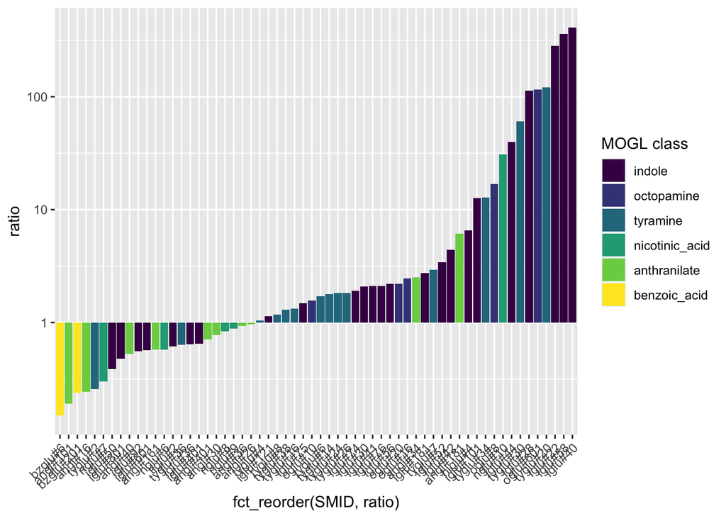

```r
plot <- sumStarved %>%
  filter(avg > 0.001,
         cest_dep == "cest-1.2",
         !is.na(SMID),
         !is.na(acylation1_2C),
         !is.na(anomeric_carbon),
         # anomeric_carbon %in% c("indole",
         #                        "tyramine",
         #                        "octopamine",
         #                        "anthranilate"),
         !(SMID == "oglu#8" &
             attachements == "octopamine pyrrolic acid (x2)")) %>%
  mutate(anomeric_carbon = fct_relevel(anomeric_carbon, "indole")) %>%
  ggplot(aes(x = fct_reorder(SMID, ratio), y = ratio)) +
  geom_bar(stat="identity", aes(fill = fct_reorder(anomeric_carbon, ratio, mean, .desc = TRUE))) +
                                                   # "indole",
                                                   # "tyramine",
                                                   # "octopamine"))) +
  scale_y_log10() +
  scale_fill_viridis_d() +
  #scale_fill_brewer(palette = "Set2") +
  guides(fill = guide_legend(title = "MOGL class")) +
  theme(axis.text.x = element_text(angle = 45, hjust = 1))

### diplay in the markdown so you can see it: ####
plot
```

Now I’m going to use the relative paths in this directory to make a new folder with this example figure and example data in it, using the name of an object we entered in the header code chunk:

```r
### make a folder
fs::dir_create('../figures/',Figure_name)

## save the plot
ggsave(plot,
       file = file.path('figures',
                 Figure_name,
                 paste0(Figure_name,'.png')))
## save the formatted edited tibble:
write_csv(sumStarved,
          file = file.path('figures',
                 Figure_name,
                 paste0(Figure_name,'.csv')))
```

figures/Example_fig/Example_fig.png